# DIID

direct inverted inverted direct

### Вопросы:

- Какие параметры влияют на образование делеций (повышают хрупкость мтДНК) = при каких комбинациях больше реализованных?
- Какое у нас ожидание?
- Какие комбинации и почему?
- Правильно ли мы считаем? Есть ли в этом биологический смысл?

### Tasklist:

- Выписать самые хрупкие (где много реализованных) и помедитировать
- % реализованных в разных комбинациях (в каких структурах высокий процент реализации)
- real/unreal
- Gq
- Пересечение OriH (110-441) и OriL (5721-5798)
- Легенда
- Код дерайва на гитхаб
- Саммари статистика
- Тесты
- Аргументация тестов
- Интерпретация тестов
- Скрестить со старыми математическими выкладками
- Перегнать множественные модели KP.DIID.md (Женя забрал себе?)
- Негативный контроль
- Все млеки
- Аналог TMS Хайдакова
- Скрестить новые анализы со старым черновиком статьи по DIID
- Сравнить real-хрупкие и real-альтернативные
- Множественная регрессия

```python
#coding=utf8
import os
import sqlite3
```

```python
# Библиотеки для манипулирования данными
import polars as pl
import pandas as pd
import numpy as np
```

### Подготовка файла со всеми комбинациями прямых и инвертированных повторов

*{за кадром: DegRepHunter}*

```python
mode = "full"    # major full

if mode == "full":
    #q = ("SELECT * FROM repeats_gap WHERE id_type = 1") #  AND length >= 12
    #q = ("SELECT * FROM repeats_gap WHERE id_type = 1  AND length >= 12")
    q = ("SELECT * FROM repeats_gap WHERE id_type = 1  AND length >= 11")

if mode == "full":
    q = ("SELECT * FROM repeats_gap WHERE id_type = 4")
```

#### Открытие файла со всеми комбинациями прямых и инвертированных повторов

```python
# Чтение данных в фрейм данных
data = pd.read_csv('Monolith.csv', sep = ';')

print(data.shape)
# Показать верхнюю часть фрейма данных
data.head(10)
```

```
(49181680, 7)
```

|  | DirArm1 | DirArm2 | DirLen | RealDel | InvArm1 | InvArm2 | InvLen |
| --- | --- | --- | --- | --- | --- | --- | --- |
| 0 | 2 | 13492 | 10 | 0 | 28 | 15142 | 10 |
| 1 | 2 | 13492 | 10 | 0 | 27 | 710 | 10 |
| 2 | 2 | 13492 | 10 | 0 | 37 | 1877 | 12 |
| 3 | 2 | 13492 | 10 | 0 | 46 | 10463 | 10 |
| 4 | 2 | 13492 | 10 | 0 | 46 | 6435 | 12 |
| 5 | 2 | 13492 | 10 | 0 | 48 | 4892 | 11 |
| 6 | 2 | 13492 | 10 | 0 | 48 | 15840 | 10 |
| 7 | 2 | 13492 | 10 | 0 | 49 | 2781 | 11 |
| 8 | 2 | 13492 | 10 | 0 | 49 | 2228 | 11 |
| 9 | 2 | 13492 | 10 | 0 | 52 | 13666 | 11 |

Планируем посмотреть на major arc of mammals and check: Грубо MajorArc с 6000 по 16000 We compare number of DI...I.D with number of D.I...ID in all mammalian species and we expect:

1. N(DI...I.D on heavy strand) < N(D.I...ID on heavy strand)
2. this difference should be more pronounced in long-lived mammals
3. for strong (long) repeats

N(DI...I.D on heavy strand) << N(D.I...ID on heavy strand)

Long Summary table D1 (interval 1) I (interval 2) I (interval 3) D:

SpeciesName

- DirectRepeat1.Motiv
- DirectRepeat1.Length
- DirectRepeat1.Location
- LengthOfInterval1
- InvertedRepeat1.Motiv
- InvertedRepeat1.Length
- InvertedRepeat1.Location
- LengthOfInterval2
- InvertedRepeat2.Motiv
- InvertedRepeat2.Length
- InvertedRepeat2.Location
- LengthOfInterval3
- DirectRepeat2.Motiv
- DirectRepeat2.Length
- DirectRepeat2.Location
- LengthOfInterval1 <= 1000 bp
- LengthOfInterval2 > 500 bp # large scale deletions
- LengthOfInterval3 <= 1000 bp

DIMENSIONALITY: (200 mammalian species X hundreds DIID for each species) ~ 40000 rows

Смотрим Fragility (соотношение DI...I.D и D.I...ID) при разных параметрах

### Легенда колонок:

- area
- loi1
- loi2
- loi3
- dii.d_unreal
- dii.d_real
- d.iid_unreal
- d.iid_real
- diid_unreal
- diid_real
- d.ii.d_unreal
- d.ii.d_real
- idd.i_unreal
- idd.i_real
- i.ddi_unreal
- i.ddi_real
- iddi_unreal
- iddi_real
- i.dd.i_unreal
- i.dd.i_real
- idi.d_unreal
- idi.d_real
- i.did_unreal
- i.did_real
- idid_unreal
- idid_real
- i.di.d_unreal
- i.di.d_real
- did.i_unreal
- did.i_real
- d.idi_unreal
- d.idi_real
- didi_unreal
- didi_real
- d.id.i_unreal
- d.id.i_real

```python
df = pd.DataFrame(columns=['area','loi1','loi2','loi3','dii.d_unreal','dii.d_real','d.iid_unreal','d.iid_real','diid_unreal','diid_real','d.ii.d_unreal','d.ii.d_real','idd.i_unreal','idd.i_real','i.ddi_unreal','i.ddi_real','iddi_unreal','iddi_real','i.dd.i_unreal','i.dd.i_real','idi.d_unreal','idi.d_real','i.did_unreal','i.did_real','idid_unreal','idid_real','i.di.d_unreal','i.di.d_real','did.i_unreal','did.i_real','d.idi_unreal','d.idi_real','didi_unreal','didi_real','d.id.i_unreal','d.id.i_real'])
df.head()
```

|  | area | loi1 | loi2 | loi3 | dii.d_unreal | dii.d_real | d.iid_unreal | d.iid_real | diid_unreal | diid_real | ... | i.di.d_unreal | i.di.d_real | did.i_unreal | did.i_real | d.idi_unreal | d.idi_real | didi_unreal | didi_real | d.id.i_unreal | d.id.i_real |
| --- | --- | --- | --- | --- | --- | --- | --- | --- | --- | --- | --- | --- | --- | --- | --- | --- | --- | --- | --- | --- | --- |

0 rows × 36 columns

```python
Tdi___i_d = 0 # хрупкие DI...I.D
Td_i___id = 0 # альтернативно хрупкие D.I...ID
Tdi_iGd = 0
TdGi_id = 0
```

DI...I.D == case

D.I...ID == altcase1

DI...ID == altcase2

D.I...I.D == altcase3

SPLIT RELIZED AND NONREALIZED

IDDI == control 1

DIDI == control 2

IDID == control 3

DDII == плохой контроль, так как типы повторов не перемешиваются - я бы выкинул из анализа

IIDD == плохой контроль, так как типы повторов не перемешиваются - я бы выкинул из анализа

0 1k 2k 3k 4k 5k 6k 7k 8k 9k 10k 11k 12k 13k 14k 15k 16k

#### Функция применеяющая параметры

```python
def dandi(area, fi,se,th,fo,loi1,loi2,loi3, real):
    # if  i[2] - (d[2]+d[4]-1) <= loi1 and i[3] - (i[2]+i[4]-1) > loi2 and d[3] - (i[3]+i[4]-1) <= loi3:
    if area == 'min':
        di = data[(((data[fi[0]] + data[fi[1]] - 1 < 6000) & (data[se[0]] + data[se[1]] - 1 < 6000)) | ((data[fi[0]] > 16000) & (data[se[0]] > 16000))) &
                  (((data[th[0]] + data[th[1]] - 1 < 6000) & (data[fo[0]] + data[fo[1]] - 1 < 6000)) | ((data[th[0]] > 16000) & (data[fo[0]] > 16000))) &
                  ((data[fi[0]] + data[fi[1]] <= data[se[0]]) & (data[th[0]] + data[th[1]] - 1 < data[fo[0]])) &
                  ((data[se[0]] - (data[fi[0]] + data[fi[1]] - 1) >= loi1[0]) & (data[se[0]] - (data[fi[0]] + data[fi[1]] - 1) <= loi1[1])) &
                  ((data[th[0]] - (data[se[0]] + data[se[1]] - 1) >= loi2[0]) & (data[th[0]] - (data[se[0]] + data[se[1]] - 1) <= loi2[1])) &
                  ((data[fo[0]] - (data[th[0]] + data[th[1]] - 1) >= loi3[0]) & (data[fo[0]] - (data[th[0]] + data[th[1]] - 1) <= loi3[1])) &
                  (data['RealDel'] == real)]
    elif area == 'maj':
        di = data[((data[fi[0]] >= 6000) & (data[se[0]] >= 6000) & (data[th[0]] >= 6000) & (data[fo[0]] >= 6000) &
                   (data[fi[0]] + data[fi[1]] - 1 <= 16000) & (data[se[0]] + data[se[1]] - 1 <= 16000) &
                   (data[th[0]] + data[th[1]] - 1 <= 16000) & (data[fo[0]] + data[fo[1]] - 1 <= 16000)) &
                  ((data[fi[0]] + data[fi[1]] <= data[se[0]]) & (data[th[0]] + data[th[1]] - 1 < data[fo[0]])) &
                  ((data[se[0]] - (data[fi[0]] + data[fi[1]] - 1) >= loi1[0]) & (data[se[0]] - (data[fi[0]] + data[fi[1]] - 1) <= loi1[1])) &
                  ((data[th[0]] - (data[se[0]] + data[se[1]] - 1) >= loi2[0]) & (data[th[0]] - (data[se[0]] + data[se[1]] - 1) <= loi2[1])) &
                  ((data[fo[0]] - (data[th[0]] + data[th[1]] - 1) >= loi3[0]) & (data[fo[0]] - (data[th[0]] + data[th[1]] - 1) <= loi3[1])) &
                  (data['RealDel'] == real)]
    return di.shape[0]
```

#### Установка параметров

```python
locs = ['0','1','2','3', '4','5','6','7', '8','9','10','11', '12','13','14','15', '16','17']

areas = ["min","maj"] # MinorArc или MajorArc
loi1s = [[0,15],[16,30]] # длина интервала 1
loi2s = [[0,5000],[5001,10000]] # длина интервала 2
loi3s = [[0,200],[201,400]] # длина интервала 3
```

```python
for area in areas:
    for loi1 in loi1s:
        for loi2 in loi2s:
            for loi3 in loi3s:

                print("%s %s_%s %s_%s %s_%s" % (area,loi1[0],loi1[1],loi2[0],loi2[1],loi3[0],loi3[1]))

                # DirArm1;DirArm2;DirLen;RealDel;InvArm1;InvArm2;InvLen
                dii_d_unreal = dandi(area,["DirArm1","DirLen"],["InvArm1","InvLen"],["InvArm2","InvLen"],["DirArm2","DirLen"],loi1,loi2,loi3,0)
                dii_d_real = dandi(area,["DirArm1","DirLen"],["InvArm1","InvLen"],["InvArm2","InvLen"],["DirArm2","DirLen"],loi1,loi2,loi3,1)
                d_iid_unreal = dandi(area,["DirArm1","DirLen"],["InvArm1","InvLen"],["InvArm2","InvLen"],["DirArm2","DirLen"],loi3,loi2,loi1,0)
                d_iid_real = dandi(area,["DirArm1","DirLen"],["InvArm1","InvLen"],["InvArm2","InvLen"],["DirArm2","DirLen"],loi3,loi2,loi1,1)
                diid_unreal = dandi(area,["DirArm1","DirLen"],["InvArm1","InvLen"],["InvArm2","InvLen"],["DirArm2","DirLen"],loi1,loi2,loi1,0)
                diid_real = dandi(area,["DirArm1","DirLen"],["InvArm1","InvLen"],["InvArm2","InvLen"],["DirArm2","DirLen"],loi1,loi2,loi1,1)
                d_ii_d_unreal = dandi(area,["DirArm1","DirLen"],["InvArm1","InvLen"],["InvArm2","InvLen"],["DirArm2","DirLen"],loi3,loi2,loi3,0)
                d_ii_d_real = dandi(area,["DirArm1","DirLen"],["InvArm1","InvLen"],["InvArm2","InvLen"],["DirArm2","DirLen"],loi3,loi2,loi3,1)

                idd_i_unreal = dandi(area,["InvArm1","InvLen"],["DirArm1","DirLen"],["DirArm2","DirLen"],["InvArm2","InvLen"],loi1,loi2,loi3,0)
                idd_i_real = dandi(area,["InvArm1","InvLen"],["DirArm1","DirLen"],["DirArm2","DirLen"],["InvArm2","InvLen"],loi1,loi2,loi3,1)
                i_ddi_unreal = dandi(area,["InvArm1","InvLen"],["DirArm1","DirLen"],["DirArm2","DirLen"],["InvArm2","InvLen"],loi3,loi2,loi1,0)
                i_ddi_real = dandi(area,["InvArm1","InvLen"],["DirArm1","DirLen"],["DirArm2","DirLen"],["InvArm2","InvLen"],loi3,loi2,loi1,1)
                iddi_unreal = dandi(area,["InvArm1","InvLen"],["DirArm1","DirLen"],["DirArm2","DirLen"],["InvArm2","InvLen"],loi1,loi2,loi1,0)
                iddi_real = dandi(area,["InvArm1","InvLen"],["DirArm1","DirLen"],["DirArm2","DirLen"],["InvArm2","InvLen"],loi1,loi2,loi1,1)
                i_dd_i_unreal = dandi(area,["InvArm1","InvLen"],["DirArm1","DirLen"],["DirArm2","DirLen"],["InvArm2","InvLen"],loi3,loi2,loi3,0)
                i_dd_i_real = dandi(area,["InvArm1","InvLen"],["DirArm1","DirLen"],["DirArm2","DirLen"],["InvArm2","InvLen"],loi3,loi2,loi3,1)

                idi_d_unreal = dandi(area,["InvArm1","InvLen"],["DirArm1","DirLen"],["InvArm2","InvLen"],["DirArm2","DirLen"],loi1,loi2,loi3,0)
                idi_d_real = dandi(area,["InvArm1","InvLen"],["DirArm1","DirLen"],["InvArm2","InvLen"],["DirArm2","DirLen"],loi1,loi2,loi3,1)
                i_did_unreal = dandi(area,["InvArm1","InvLen"],["DirArm1","DirLen"],["InvArm2","InvLen"],["DirArm2","DirLen"],loi3,loi2,loi1,0)
                i_did_real = dandi(area,["InvArm1","InvLen"],["DirArm1","DirLen"],["InvArm2","InvLen"],["DirArm2","DirLen"],loi3,loi2,loi1,1)
                idid_unreal = dandi(area,["InvArm1","InvLen"],["DirArm1","DirLen"],["InvArm2","InvLen"],["DirArm2","DirLen"],loi1,loi2,loi1,0)
                idid_real = dandi(area,["InvArm1","InvLen"],["DirArm1","DirLen"],["InvArm2","InvLen"],["DirArm2","DirLen"],loi1,loi2,loi1,1)
                i_di_d_unreal = dandi(area,["InvArm1","InvLen"],["DirArm1","DirLen"],["InvArm2","InvLen"],["DirArm2","DirLen"],loi3,loi2,loi3,0)
                i_di_d_real = dandi(area,["InvArm1","InvLen"],["DirArm1","DirLen"],["InvArm2","InvLen"],["DirArm2","DirLen"],loi3,loi2,loi3,1)

                did_i_unreal = dandi(area,["DirArm1","DirLen"],["InvArm1","InvLen"],["DirArm2","DirLen"],["InvArm2","InvLen"],loi1,loi2,loi3,0)
                did_i_real = dandi(area,["DirArm1","DirLen"],["InvArm1","InvLen"],["DirArm2","DirLen"],["InvArm2","InvLen"],loi1,loi2,loi3,1)
                d_idi_unreal = dandi(area,["DirArm1","DirLen"],["InvArm1","InvLen"],["DirArm2","DirLen"],["InvArm2","InvLen"],loi3,loi2,loi1,0)
                d_idi_real = dandi(area,["DirArm1","DirLen"],["InvArm1","InvLen"],["DirArm2","DirLen"],["InvArm2","InvLen"],loi3,loi2,loi1,1)
                didi_unreal = dandi(area,["DirArm1","DirLen"],["InvArm1","InvLen"],["DirArm2","DirLen"],["InvArm2","InvLen"],loi1,loi2,loi1,0)
                didi_real = dandi(area,["DirArm1","DirLen"],["InvArm1","InvLen"],["DirArm2","DirLen"],["InvArm2","InvLen"],loi1,loi2,loi1,1)
                d_id_i_unreal = dandi(area,["DirArm1","DirLen"],["InvArm1","InvLen"],["DirArm2","DirLen"],["InvArm2","InvLen"],loi3,loi2,loi3,0)
                d_id_i_real = dandi(area,["DirArm1","DirLen"],["InvArm1","InvLen"],["DirArm2","DirLen"],["InvArm2","InvLen"],loi3,loi2,loi3,1)

                temp = pd.DataFrame([[area,str(loi1[0])+'_'+str(loi1[1]),str(loi2[0])+'_'+str(loi2[1]),str(loi3[0])+'_'+str(loi3[1]),dii_d_unreal,dii_d_real,d_iid_unreal,d_iid_real,diid_unreal,diid_real,d_ii_d_unreal,d_ii_d_real,idd_i_unreal,idd_i_real,i_ddi_unreal,i_ddi_real,iddi_unreal,iddi_real,i_dd_i_unreal,i_dd_i_real,idi_d_unreal,idi_d_real,i_did_unreal,i_did_real,idid_unreal,idid_real,i_di_d_unreal,i_di_d_real,did_i_unreal,did_i_real,d_idi_unreal,d_idi_real,didi_unreal,didi_real,d_id_i_unreal,d_id_i_real]],
                                             columns = ['area','loi1','loi2','loi3','dii.d_unreal','dii.d_real','d.iid_unreal','d.iid_real','diid_unreal','diid_real','d.ii.d_unreal','d.ii.d_real','idd.i_unreal','idd.i_real','i.ddi_unreal','i.ddi_real','iddi_unreal','iddi_real','i.dd.i_unreal','i.dd.i_real','idi.d_unreal','idi.d_real','i.did_unreal','i.did_real','idid_unreal','idid_real','i.di.d_unreal','i.di.d_real','did.i_unreal','did.i_real','d.idi_unreal','d.idi_real','didi_unreal','didi_real','d.id.i_unreal','d.id.i_real'])
                df = pd.concat([df, temp])
```

```
min 0_15 0_5000 0_200
min 0_15 0_5000 201_400
min 0_15 5001_10000 0_200
min 0_15 5001_10000 201_400
min 16_30 0_5000 0_200
min 16_30 0_5000 201_400
min 16_30 5001_10000 0_200
min 16_30 5001_10000 201_400
maj 0_15 0_5000 0_200
maj 0_15 0_5000 201_400
maj 0_15 5001_10000 0_200
maj 0_15 5001_10000 201_400
maj 16_30 0_5000 0_200
maj 16_30 0_5000 201_400
maj 16_30 5001_10000 0_200
maj 16_30 5001_10000 201_400
```

```python
#df.to_csv("Result.csv", sep=';', encoding='utf-8')
```

```python
df = pl.read_csv(r"C:\Users\Abathur\Desktop\_SCIENCE\DIID\NewAnal\Result.csv", separator=";")
#df = df.filter( (pl.col('dii.d_real').is_not_null()) )
df
```

shape: (16, 37)

| i64 | area str | loi1 str | loi2 str | loi3 str | dii.d_unreal i64 | dii.d_real i64 | d.iid_unreal i64 | d.iid_real i64 | diid_unreal i64 | diid_real i64 | d.ii.d_unreal i64 | d.ii.d_real i64 | idd.i_unreal i64 | idd.i_real i64 | i.ddi_unreal i64 | i.ddi_real i64 | iddi_unreal i64 | iddi_real i64 | i.dd.i_unreal i64 | i.dd.i_real i64 | idi.d_unreal i64 | idi.d_real i64 | i.did_unreal i64 | i.did_real i64 | idid_unreal i64 | idid_real i64 | i.di.d_unreal i64 | i.di.d_real i64 | did.i_unreal i64 | … |
| --- | --- | --- | --- | --- | --- | --- | --- | --- | --- | --- | --- | --- | --- | --- | --- | --- | --- | --- | --- | --- | --- | --- | --- | --- | --- | --- | --- | --- | --- | --- |
| 0 | "min" | "0_15" | "0_5000" | "0_200" | 41 | 0 | 26 | 1 | 4 | 0 | 446 | 2 | 36 | 1 | 41 | 0 | 3 | 0 | 450 | 12 | 27 | 0 | 24 | 1 | 2 | 0 | 426 | 6 | 40 | … |
| 0 | "min" | "0_15" | "0_5000" | "201_400" | 36 | 0 | 34 | 0 | 4 | 0 | 375 | 3 | 23 | 0 | 27 | 0 | 3 | 0 | 385 | 12 | 33 | 0 | 33 | 0 | 2 | 0 | 387 | 6 | 40 | … |
| 0 | "min" | "0_15" | "5001_10000" | "0_200" | 8 | 0 | 2 | 0 | 0 | 0 | 38 | 0 | 3 | 0 | 4 | 0 | 1 | 0 | 46 | 0 | 4 | 0 | 1 | 0 | 0 | 0 | 66 | 0 | 5 | … |
| 0 | "min" | "0_15" | "5001_10000" | "201_400" | 2 | 0 | 0 | 0 | 0 | 0 | 21 | 0 | 4 | 0 | 0 | 0 | 1 | 0 | 23 | 0 | 3 | 0 | 5 | 0 | 0 | 0 | 35 | 0 | 1 | … |
| 0 | "min" | "16_30" | "0_5000" | "0_200" | 37 | 0 | 47 | 0 | 3 | 0 | 446 | 2 | 49 | 3 | 33 | 0 | 3 | 0 | 450 | 12 | 32 | 0 | 31 | 0 | 7 | 0 | 426 | 6 | 18 | … |
| … | … | … | … | … | … | … | … | … | … | … | … | … | … | … | … | … | … | … | … | … | … | … | … | … | … | … | … | … | … | … |
| 0 | "maj" | "0_15" | "5001_10000" | "201_400" | 19 | 4 | 18 | 4 | 1 | 0 | 160 | 43 | 20 | 6 | 18 | 4 | 1 | 0 | 212 | 63 | 18 | 6 | 22 | 6 | 0 | 0 | 191 | 53 | 9 | … |
| 0 | "maj" | "16_30" | "0_5000" | "0_200" | 69 | 1 | 70 | 1 | 5 | 0 | 834 | 37 | 57 | 0 | 81 | 2 | 8 | 0 | 902 | 35 | 78 | 6 | 77 | 1 | 4 | 1 | 953 | 44 | 81 | … |
| 0 | "maj" | "16_30" | "0_5000" | "201_400" | 75 | 5 | 82 | 3 | 5 | 0 | 870 | 62 | 74 | 2 | 84 | 3 | 8 | 0 | 911 | 26 | 64 | 5 | 67 | 3 | 4 | 1 | 852 | 46 | 74 | … |
| 0 | "maj" | "16_30" | "5001_10000" | "0_200" | 21 | 3 | 15 | 6 | 1 | 1 | 203 | 41 | 12 | 5 | 15 | 5 | 0 | 1 | 228 | 58 | 13 | 4 | 9 | 8 | 0 | 0 | 196 | 62 | 9 | … |
| 0 | "maj" | "16_30" | "5001_10000" | "201_400" | 16 | 4 | 15 | 1 | 1 | 1 | 160 | 43 | 17 | 1 | 18 | 6 | 0 | 1 | 212 | 63 | 15 | 1 | 16 | 3 | 0 | 0 | 191 | 53 | 15 | … |

```python
df['dii.d_real'].describe()
```

shape: (9, 2)

| statistic str | value f64 |
| --- | --- |
| "count" | 16.0 |
| "null_count" | 0.0 |
| "mean" | 2.0625 |
| "std" | 2.264766 |
| "min" | 0.0 |
| "25%" | 0.0 |
| "50%" | 1.0 |
| "75%" | 4.0 |
| "max" | 6.0 |

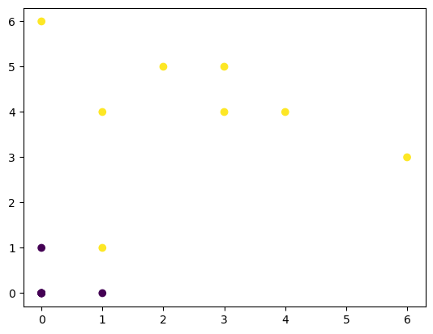

```python
import matplotlib.pyplot as plt
fig, ax = plt.subplots()
ax.scatter(
    x=df['d.iid_real'],
    y=df['dii.d_real'],
    c=df['area'].cast(pl.Categorical).to_physical(),
)
```

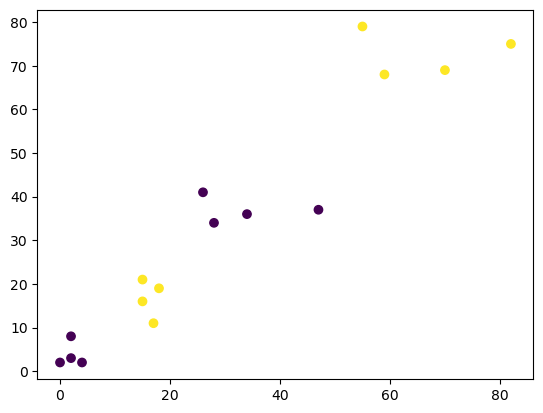

```python
import matplotlib.pyplot as plt
fig, ax = plt.subplots()
ax.scatter(
    x=df['d.iid_unreal'],
    y=df['dii.d_unreal'],
    c=df['area'].cast(pl.Categorical).to_physical(),
)
```

```python
df = df.with_columns((pl.col('loi1').map_elements(lambda x: int(x.split('_')[0])).alias('loi1start')))
df = df.with_columns((pl.col('loi1').map_elements(lambda x: int(x.split('_')[1])).alias('loi1end')))
df = df.with_columns((pl.col('loi2').map_elements(lambda x: int(x.split('_')[0])).alias('loi2start')))
df = df.with_columns((pl.col('loi2').map_elements(lambda x: int(x.split('_')[1])).alias('loi2end')))
df = df.with_columns((pl.col('loi3').map_elements(lambda x: int(x.split('_')[0])).alias('loi3start')))
df = df.with_columns((pl.col('loi3').map_elements(lambda x: int(x.split('_')[1])).alias('loi3end')))
df
```

shape: (16, 43)

| i64 | area str | loi1 str | loi2 str | loi3 str | dii.d_unreal i64 | dii.d_real i64 | d.iid_unreal i64 | d.iid_real i64 | diid_unreal i64 | diid_real i64 | d.ii.d_unreal i64 | d.ii.d_real i64 | idd.i_unreal i64 | idd.i_real i64 | i.ddi_unreal i64 | i.ddi_real i64 | iddi_unreal i64 | iddi_real i64 | i.dd.i_unreal i64 | i.dd.i_real i64 | idi.d_unreal i64 | idi.d_real i64 | i.did_unreal i64 | i.did_real i64 | idid_unreal i64 | idid_real i64 | i.di.d_unreal i64 | i.di.d_real i64 | did.i_unreal i64 | … |
| --- | --- | --- | --- | --- | --- | --- | --- | --- | --- | --- | --- | --- | --- | --- | --- | --- | --- | --- | --- | --- | --- | --- | --- | --- | --- | --- | --- | --- | --- | --- |
| 0 | "min" | "0_15" | "0_5000" | "0_200" | 41 | 0 | 26 | 1 | 4 | 0 | 446 | 2 | 36 | 1 | 41 | 0 | 3 | 0 | 450 | 12 | 27 | 0 | 24 | 1 | 2 | 0 | 426 | 6 | 40 | … |
| 0 | "min" | "0_15" | "0_5000" | "201_400" | 36 | 0 | 34 | 0 | 4 | 0 | 375 | 3 | 23 | 0 | 27 | 0 | 3 | 0 | 385 | 12 | 33 | 0 | 33 | 0 | 2 | 0 | 387 | 6 | 40 | … |
| 0 | "min" | "0_15" | "5001_10000" | "0_200" | 8 | 0 | 2 | 0 | 0 | 0 | 38 | 0 | 3 | 0 | 4 | 0 | 1 | 0 | 46 | 0 | 4 | 0 | 1 | 0 | 0 | 0 | 66 | 0 | 5 | … |
| 0 | "min" | "0_15" | "5001_10000" | "201_400" | 2 | 0 | 0 | 0 | 0 | 0 | 21 | 0 | 4 | 0 | 0 | 0 | 1 | 0 | 23 | 0 | 3 | 0 | 5 | 0 | 0 | 0 | 35 | 0 | 1 | … |
| 0 | "min" | "16_30" | "0_5000" | "0_200" | 37 | 0 | 47 | 0 | 3 | 0 | 446 | 2 | 49 | 3 | 33 | 0 | 3 | 0 | 450 | 12 | 32 | 0 | 31 | 0 | 7 | 0 | 426 | 6 | 18 | … |
| … | … | … | … | … | … | … | … | … | … | … | … | … | … | … | … | … | … | … | … | … | … | … | … | … | … | … | … | … | … | … |
| 0 | "maj" | "0_15" | "5001_10000" | "201_400" | 19 | 4 | 18 | 4 | 1 | 0 | 160 | 43 | 20 | 6 | 18 | 4 | 1 | 0 | 212 | 63 | 18 | 6 | 22 | 6 | 0 | 0 | 191 | 53 | 9 | … |
| 0 | "maj" | "16_30" | "0_5000" | "0_200" | 69 | 1 | 70 | 1 | 5 | 0 | 834 | 37 | 57 | 0 | 81 | 2 | 8 | 0 | 902 | 35 | 78 | 6 | 77 | 1 | 4 | 1 | 953 | 44 | 81 | … |
| 0 | "maj" | "16_30" | "0_5000" | "201_400" | 75 | 5 | 82 | 3 | 5 | 0 | 870 | 62 | 74 | 2 | 84 | 3 | 8 | 0 | 911 | 26 | 64 | 5 | 67 | 3 | 4 | 1 | 852 | 46 | 74 | … |
| 0 | "maj" | "16_30" | "5001_10000" | "0_200" | 21 | 3 | 15 | 6 | 1 | 1 | 203 | 41 | 12 | 5 | 15 | 5 | 0 | 1 | 228 | 58 | 13 | 4 | 9 | 8 | 0 | 0 | 196 | 62 | 9 | … |
| 0 | "maj" | "16_30" | "5001_10000" | "201_400" | 16 | 4 | 15 | 1 | 1 | 1 | 160 | 43 | 17 | 1 | 18 | 6 | 0 | 1 | 212 | 63 | 15 | 1 | 16 | 3 | 0 | 0 | 191 | 53 | 15 | … |

```python
df_pandas = df.to_pandas()
```

```python
nums = df_pandas.select_dtypes('number')
corrs_df = nums.corr()['dii.d_real'].sort_values()
corrs_df
```

```
loi1end         -0.142509
loi1start       -0.142509
loi2end         -0.085505
loi2start       -0.085505
idid_unreal     -0.023772
idid_real        0.161590
loi3end          0.199512
loi3start        0.199512
diid_real        0.247771
iddi_real        0.247771
didi_unreal      0.253162
iddi_unreal      0.266401
diid_unreal      0.411941
did.i_unreal     0.448151
d.iid_unreal     0.461021
i.di.d_unreal    0.489485
dii.d_unreal     0.491822
idi.d_unreal     0.495900
i.ddi_unreal     0.500528
d.ii.d_unreal    0.503036
d.id.i_unreal    0.518952
d.idi_unreal     0.520286
i.did_unreal     0.529826
d.iid_real       0.530010
i.did_real       0.532636
idd.i_unreal     0.532759
i.dd.i_unreal    0.532905
i.ddi_real       0.636505
did.i_real       0.648938
idd.i_real       0.654681
idi.d_real       0.671715
i.dd.i_real      0.705388
d.idi_real       0.740281
d.id.i_real      0.817142
i.di.d_real      0.851714
d.ii.d_real      0.933278
dii.d_real       1.000000
                      NaN
didi_real             NaN
Name: dii.d_real, dtype: float64
```

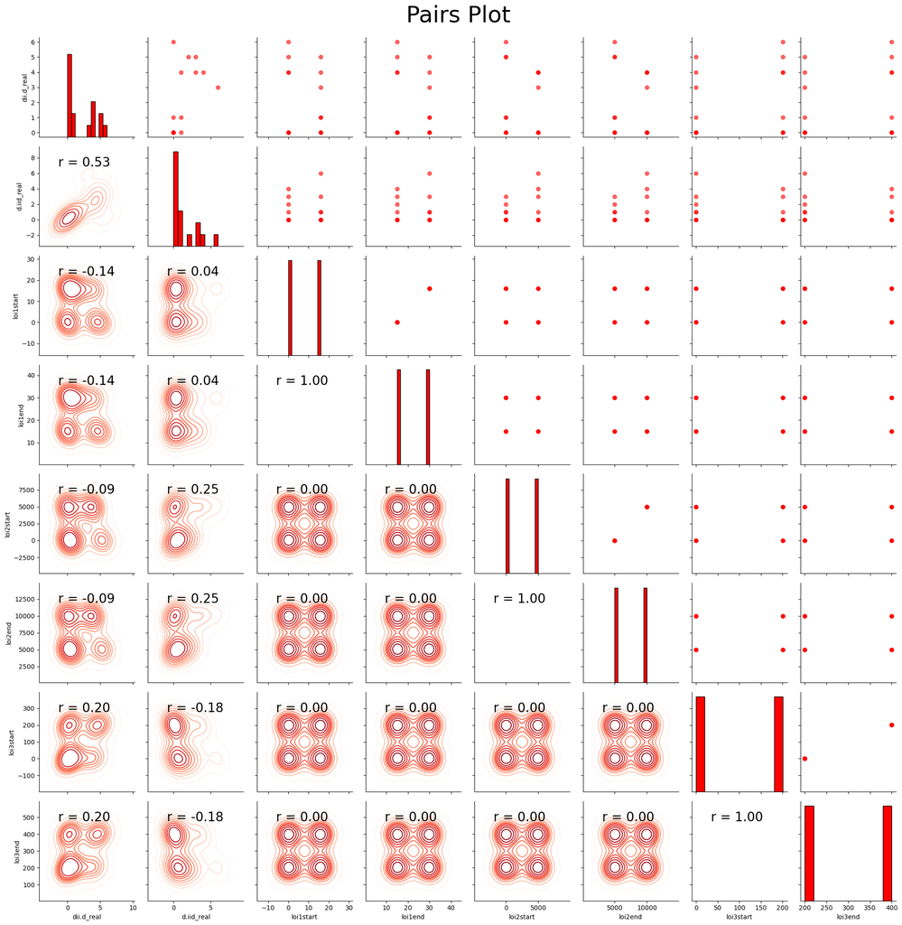

```python
import seaborn as sns
# Извлеките столбцы для построения графика
plot_data = nums[['dii.d_real', #'G',
                      'd.iid_real',
                      'loi1start',
                      'loi1end',
                      'loi2start',
                      'loi2end',
                      'loi3start',
                      'loi3end']]

# Функция для расчета коэффициента корреляции между двумя столбцами
def corr_func(x, y, **kwargs):
    r = np.corrcoef(x, y)[0][1]
    ax = plt.gca()
    ax.annotate("r = {:.2f}".format(r),
                xy=(.2, .8), xycoords=ax.transAxes,
                size = 20)

# Создайте объект pairgrid
grid = sns.PairGrid(data = plot_data)

# Вверху - диаграмма рассеяния
grid.map_upper(plt.scatter, color = 'red', alpha = 0.6)

# Диагональ - это гистограмма
grid.map_diag(plt.hist, color = 'red', edgecolor = 'black')

# Внизу график корреляции и плотности.
grid.map_lower(corr_func);
grid.map_lower(sns.kdeplot, cmap = plt.cm.Reds)

# Название всего графика
plt.suptitle('Pairs Plot', size = 36, y = 1.02);
```

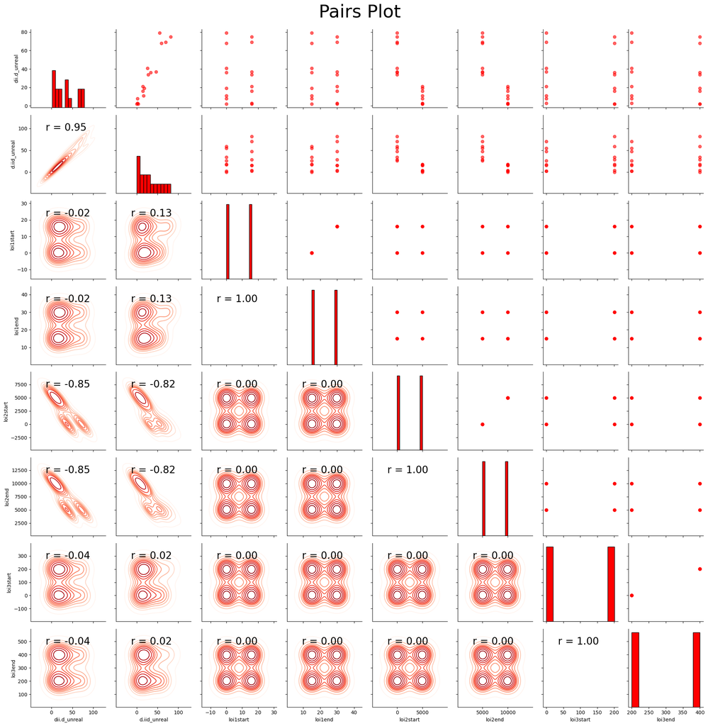

```python
plot_data = nums[['dii.d_unreal', #'G',
                      'd.iid_unreal',
                      'loi1start',
                      'loi1end',
                      'loi2start',
                      'loi2end',
                      'loi3start',
                      'loi3end']]

# Создайте объект pairgrid
grid = sns.PairGrid(data = plot_data)

# Вверху - диаграмма рассеяния
grid.map_upper(plt.scatter, color = 'red', alpha = 0.6)

# Диагональ - это гистограмма
grid.map_diag(plt.hist, color = 'red', edgecolor = 'black')

# Внизу график корреляции и плотности.
grid.map_lower(corr_func);
grid.map_lower(sns.kdeplot, cmap = plt.cm.Reds)

# Название всего графика
plt.suptitle('Pairs Plot', size = 36, y = 1.02);
```

```python
dfperc = df
def realproc(com):
    global dfperc
    dfperc = dfperc.with_columns(
        pl.struct(
            [com + '_unreal',com +'_real']
        ).map_elements(
            lambda x:  (
                int( x[com +'_real'] / ( (x[com + '_unreal'] + x[com +'_real']) / 100) )
                if x[com +'_real']>0 else 0
            )
        ).alias(
            com+'_realperc'

        )

    )


realproc('dii.d')
realproc('d.iid')
realproc('diid')
realproc('d.ii.d')
realproc('idd.i')
realproc('i.ddi')
realproc('iddi')
realproc('i.dd.i')
realproc('idi.d')
realproc('i.did')
realproc('idid')
realproc('i.di.d')
realproc('did.i')
realproc('d.idi')
realproc('didi')
realproc('d.id.i')
dfperc
```

[output not shown]

[output cut: 8 more lines]

[output not shown]

shape: (16, 59)

| i64 | area str | loi1 str | loi2 str | loi3 str | dii.d_unreal i64 | dii.d_real i64 | d.iid_unreal i64 | d.iid_real i64 | diid_unreal i64 | diid_real i64 | d.ii.d_unreal i64 | d.ii.d_real i64 | idd.i_unreal i64 | idd.i_real i64 | i.ddi_unreal i64 | i.ddi_real i64 | iddi_unreal i64 | iddi_real i64 | i.dd.i_unreal i64 | i.dd.i_real i64 | idi.d_unreal i64 | idi.d_real i64 | i.did_unreal i64 | i.did_real i64 | idid_unreal i64 | idid_real i64 | i.di.d_unreal i64 | i.di.d_real i64 | did.i_unreal i64 | … |
| --- | --- | --- | --- | --- | --- | --- | --- | --- | --- | --- | --- | --- | --- | --- | --- | --- | --- | --- | --- | --- | --- | --- | --- | --- | --- | --- | --- | --- | --- | --- |
| 0 | "min" | "0_15" | "0_5000" | "0_200" | 41 | 0 | 26 | 1 | 4 | 0 | 446 | 2 | 36 | 1 | 41 | 0 | 3 | 0 | 450 | 12 | 27 | 0 | 24 | 1 | 2 | 0 | 426 | 6 | 40 | … |
| 0 | "min" | "0_15" | "0_5000" | "201_400" | 36 | 0 | 34 | 0 | 4 | 0 | 375 | 3 | 23 | 0 | 27 | 0 | 3 | 0 | 385 | 12 | 33 | 0 | 33 | 0 | 2 | 0 | 387 | 6 | 40 | … |
| 0 | "min" | "0_15" | "5001_10000" | "0_200" | 8 | 0 | 2 | 0 | 0 | 0 | 38 | 0 | 3 | 0 | 4 | 0 | 1 | 0 | 46 | 0 | 4 | 0 | 1 | 0 | 0 | 0 | 66 | 0 | 5 | … |
| 0 | "min" | "0_15" | "5001_10000" | "201_400" | 2 | 0 | 0 | 0 | 0 | 0 | 21 | 0 | 4 | 0 | 0 | 0 | 1 | 0 | 23 | 0 | 3 | 0 | 5 | 0 | 0 | 0 | 35 | 0 | 1 | … |
| 0 | "min" | "16_30" | "0_5000" | "0_200" | 37 | 0 | 47 | 0 | 3 | 0 | 446 | 2 | 49 | 3 | 33 | 0 | 3 | 0 | 450 | 12 | 32 | 0 | 31 | 0 | 7 | 0 | 426 | 6 | 18 | … |
| … | … | … | … | … | … | … | … | … | … | … | … | … | … | … | … | … | … | … | … | … | … | … | … | … | … | … | … | … | … | … |
| 0 | "maj" | "0_15" | "5001_10000" | "201_400" | 19 | 4 | 18 | 4 | 1 | 0 | 160 | 43 | 20 | 6 | 18 | 4 | 1 | 0 | 212 | 63 | 18 | 6 | 22 | 6 | 0 | 0 | 191 | 53 | 9 | … |
| 0 | "maj" | "16_30" | "0_5000" | "0_200" | 69 | 1 | 70 | 1 | 5 | 0 | 834 | 37 | 57 | 0 | 81 | 2 | 8 | 0 | 902 | 35 | 78 | 6 | 77 | 1 | 4 | 1 | 953 | 44 | 81 | … |
| 0 | "maj" | "16_30" | "0_5000" | "201_400" | 75 | 5 | 82 | 3 | 5 | 0 | 870 | 62 | 74 | 2 | 84 | 3 | 8 | 0 | 911 | 26 | 64 | 5 | 67 | 3 | 4 | 1 | 852 | 46 | 74 | … |
| 0 | "maj" | "16_30" | "5001_10000" | "0_200" | 21 | 3 | 15 | 6 | 1 | 1 | 203 | 41 | 12 | 5 | 15 | 5 | 0 | 1 | 228 | 58 | 13 | 4 | 9 | 8 | 0 | 0 | 196 | 62 | 9 | … |
| 0 | "maj" | "16_30" | "5001_10000" | "201_400" | 16 | 4 | 15 | 1 | 1 | 1 | 160 | 43 | 17 | 1 | 18 | 6 | 0 | 1 | 212 | 63 | 15 | 1 | 16 | 3 | 0 | 0 | 191 | 53 | 15 | … |

```python
dfperc=dfperc.select(pl.col("area","loi1","loi2","loi3","dii.d_realperc","d.iid_realperc","diid_realperc","d.ii.d_realperc","idd.i_realperc","i.ddi_realperc","iddi_realperc","i.dd.i_realperc","idi.d_realperc","i.did_realperc","idid_realperc","i.di.d_realperc","did.i_realperc","d.idi_realperc","didi_realperc","d.id.i_realperc"))
dfperc
```

shape: (16, 20)

| area str | loi1 str | loi2 str | loi3 str | dii.d_realperc i64 | d.iid_realperc i64 | diid_realperc i64 | d.ii.d_realperc i64 | idd.i_realperc i64 | i.ddi_realperc i64 | iddi_realperc i64 | i.dd.i_realperc i64 | idi.d_realperc i64 | i.did_realperc i64 | idid_realperc i64 | i.di.d_realperc i64 | did.i_realperc i64 | d.idi_realperc i64 | didi_realperc i64 | d.id.i_realperc i64 |
| --- | --- | --- | --- | --- | --- | --- | --- | --- | --- | --- | --- | --- | --- | --- | --- | --- | --- | --- | --- |
| "min" | "0_15" | "0_5000" | "0_200" | 0 | 3 | 0 | 0 | 2 | 0 | 0 | 2 | 0 | 4 | 0 | 1 | 2 | 0 | 0 | 2 |
| "min" | "0_15" | "0_5000" | "201_400" | 0 | 0 | 0 | 0 | 0 | 0 | 0 | 3 | 0 | 0 | 0 | 1 | 0 | 0 | 0 | 0 |
| "min" | "0_15" | "5001_10000" | "0_200" | 0 | 0 | 0 | 0 | 0 | 0 | 0 | 0 | 0 | 0 | 0 | 0 | 0 | 0 | 0 | 0 |
| "min" | "0_15" | "5001_10000" | "201_400" | 0 | 0 | 0 | 0 | 0 | 0 | 0 | 0 | 0 | 0 | 0 | 0 | 0 | 0 | 0 | 0 |
| "min" | "16_30" | "0_5000" | "0_200" | 0 | 0 | 0 | 0 | 5 | 0 | 0 | 2 | 0 | 0 | 0 | 1 | 0 | 3 | 0 | 2 |
| … | … | … | … | … | … | … | … | … | … | … | … | … | … | … | … | … | … | … | … |
| "maj" | "0_15" | "5001_10000" | "201_400" | 17 | 18 | 0 | 21 | 23 | 18 | 0 | 22 | 25 | 21 | 0 | 21 | 35 | 21 | 0 | 20 |
| "maj" | "16_30" | "0_5000" | "0_200" | 1 | 1 | 0 | 4 | 0 | 2 | 0 | 3 | 7 | 1 | 20 | 4 | 2 | 1 | 0 | 3 |
| "maj" | "16_30" | "0_5000" | "201_400" | 6 | 3 | 0 | 6 | 2 | 3 | 0 | 2 | 7 | 4 | 20 | 5 | 3 | 1 | 0 | 4 |
| "maj" | "16_30" | "5001_10000" | "0_200" | 12 | 28 | 50 | 16 | 29 | 25 | 100 | 20 | 23 | 47 | 0 | 24 | 43 | 30 | 0 | 24 |
| "maj" | "16_30" | "5001_10000" | "201_400" | 20 | 6 | 50 | 21 | 5 | 25 | 100 | 22 | 6 | 15 | 0 | 21 | 16 | 12 | 0 | 20 |

```python
import pandas as pd
dfperc_num = dfperc.select(pl.col("dii.d_realperc", "d.iid_realperc", "diid_realperc", "d.ii.d_realperc", "idd.i_realperc", "i.ddi_realperc", "iddi_realperc", "i.dd.i_realperc", "idi.d_realperc", "i.did_realperc", "idid_realperc", "i.di.d_realperc", "did.i_realperc", "d.idi_realperc", "didi_realperc", "d.id.i_realperc"))
dfperc_num_pandas = dfperc_num.to_pandas()
dfperc_num_pandas
```

|  | dii.d_realperc | d.iid_realperc | diid_realperc | d.ii.d_realperc | idd.i_realperc | i.ddi_realperc | iddi_realperc | i.dd.i_realperc | idi.d_realperc | i.did_realperc | idid_realperc | i.di.d_realperc | did.i_realperc | d.idi_realperc | didi_realperc | d.id.i_realperc |
| --- | --- | --- | --- | --- | --- | --- | --- | --- | --- | --- | --- | --- | --- | --- | --- | --- |
| 0 | 0 | 3 | 0 | 0 | 2 | 0 | 0 | 2 | 0 | 4 | 0 | 1 | 2 | 0 | 0 | 2 |
| 1 | 0 | 0 | 0 | 0 | 0 | 0 | 0 | 3 | 0 | 0 | 0 | 1 | 0 | 0 | 0 | 0 |
| 2 | 0 | 0 | 0 | 0 | 0 | 0 | 0 | 0 | 0 | 0 | 0 | 0 | 0 | 0 | 0 | 0 |
| 3 | 0 | 0 | 0 | 0 | 0 | 0 | 0 | 0 | 0 | 0 | 0 | 0 | 0 | 0 | 0 | 0 |
| 4 | 0 | 0 | 0 | 0 | 5 | 0 | 0 | 2 | 0 | 0 | 0 | 1 | 0 | 3 | 0 | 2 |
| 5 | 2 | 0 | 0 | 0 | 5 | 6 | 0 | 3 | 3 | 4 | 0 | 1 | 0 | 0 | 0 | 0 |
| 6 | 0 | 0 | 0 | 0 | 0 | 0 | 0 | 0 | 0 | 0 | 0 | 0 | 0 | 0 | 0 | 0 |
| 7 | 0 | 0 | 0 | 0 | 0 | 0 | 0 | 0 | 0 | 0 | 0 | 0 | 0 | 0 | 0 | 0 |
| 8 | 5 | 3 | 0 | 4 | 2 | 2 | 0 | 3 | 2 | 3 | 0 | 4 | 2 | 5 | 0 | 3 |
| 9 | 8 | 0 | 0 | 6 | 7 | 1 | 0 | 2 | 6 | 0 | 0 | 5 | 2 | 10 | 0 | 4 |
| 10 | 26 | 15 | 0 | 16 | 10 | 12 | 0 | 20 | 13 | 31 | 0 | 24 | 43 | 11 | 0 | 24 |
| 11 | 17 | 18 | 0 | 21 | 23 | 18 | 0 | 22 | 25 | 21 | 0 | 21 | 35 | 21 | 0 | 20 |
| 12 | 1 | 1 | 0 | 4 | 0 | 2 | 0 | 3 | 7 | 1 | 20 | 4 | 2 | 1 | 0 | 3 |
| 13 | 6 | 3 | 0 | 6 | 2 | 3 | 0 | 2 | 7 | 4 | 20 | 5 | 3 | 1 | 0 | 4 |
| 14 | 12 | 28 | 50 | 16 | 29 | 25 | 100 | 20 | 23 | 47 | 0 | 24 | 43 | 30 | 0 | 24 |
| 15 | 20 | 6 | 50 | 21 | 5 | 25 | 100 | 22 | 6 | 15 | 0 | 21 | 16 | 12 | 0 | 20 |

```python
res = {i:dfperc_num_pandas.loc[i].sort_values(ascending=False) for i in dfperc_num_pandas.index}
res
```

```
{0: i.did_realperc     4
 d.iid_realperc     3
 idd.i_realperc     2
 i.dd.i_realperc    2
 did.i_realperc     2
 d.id.i_realperc    2
 i.di.d_realperc    1
 dii.d_realperc     0
 diid_realperc      0
 d.ii.d_realperc    0
 i.ddi_realperc     0
 iddi_realperc      0
 idi.d_realperc     0
 idid_realperc      0
 d.idi_realperc     0
 didi_realperc      0
 Name: 0, dtype: int64,
 1: i.dd.i_realperc    3
 i.di.d_realperc    1
 dii.d_realperc     0
 d.iid_realperc     0
 diid_realperc      0
 d.ii.d_realperc    0
 idd.i_realperc     0
 i.ddi_realperc     0
 iddi_realperc      0
 idi.d_realperc     0
 i.did_realperc     0
 idid_realperc      0
 did.i_realperc     0
 d.idi_realperc     0
 didi_realperc      0
 d.id.i_realperc    0
 Name: 1, dtype: int64,
 2: dii.d_realperc     0
 d.iid_realperc     0
 diid_realperc      0
 d.ii.d_realperc    0
 idd.i_realperc     0
 i.ddi_realperc     0
```

[output cut: 217 more lines]

```
 i.ddi_realperc      25
 i.dd.i_realperc     22
 d.ii.d_realperc     21
 i.di.d_realperc     21
 dii.d_realperc      20
 d.id.i_realperc     20
 did.i_realperc      16
 i.did_realperc      15
 d.idi_realperc      12
 d.iid_realperc       6
 idi.d_realperc       6
 idd.i_realperc       5
 idid_realperc        0
 didi_realperc        0
 Name: 15, dtype: int64}
```

```python
a = dfperc_num_pandas.sum().sort_values(ascending=False)
b = pd.concat((a[a.gt(0)],a[a.lt(0)].sort_values(),a[a.eq(0)]))
out = dfperc_num_pandas.reindex(columns=b.index)
out
```

|  | iddi_realperc | did.i_realperc | i.did_realperc | i.di.d_realperc | d.id.i_realperc | i.dd.i_realperc | diid_realperc | dii.d_realperc | d.ii.d_realperc | i.ddi_realperc | d.idi_realperc | idi.d_realperc | idd.i_realperc | d.iid_realperc | idid_realperc | didi_realperc |
| --- | --- | --- | --- | --- | --- | --- | --- | --- | --- | --- | --- | --- | --- | --- | --- | --- |
| 0 | 0 | 2 | 4 | 1 | 2 | 2 | 0 | 0 | 0 | 0 | 0 | 0 | 2 | 3 | 0 | 0 |
| 1 | 0 | 0 | 0 | 1 | 0 | 3 | 0 | 0 | 0 | 0 | 0 | 0 | 0 | 0 | 0 | 0 |
| 2 | 0 | 0 | 0 | 0 | 0 | 0 | 0 | 0 | 0 | 0 | 0 | 0 | 0 | 0 | 0 | 0 |
| 3 | 0 | 0 | 0 | 0 | 0 | 0 | 0 | 0 | 0 | 0 | 0 | 0 | 0 | 0 | 0 | 0 |
| 4 | 0 | 0 | 0 | 1 | 2 | 2 | 0 | 0 | 0 | 0 | 3 | 0 | 5 | 0 | 0 | 0 |
| 5 | 0 | 0 | 4 | 1 | 0 | 3 | 0 | 2 | 0 | 6 | 0 | 3 | 5 | 0 | 0 | 0 |
| 6 | 0 | 0 | 0 | 0 | 0 | 0 | 0 | 0 | 0 | 0 | 0 | 0 | 0 | 0 | 0 | 0 |
| 7 | 0 | 0 | 0 | 0 | 0 | 0 | 0 | 0 | 0 | 0 | 0 | 0 | 0 | 0 | 0 | 0 |
| 8 | 0 | 2 | 3 | 4 | 3 | 3 | 0 | 5 | 4 | 2 | 5 | 2 | 2 | 3 | 0 | 0 |
| 9 | 0 | 2 | 0 | 5 | 4 | 2 | 0 | 8 | 6 | 1 | 10 | 6 | 7 | 0 | 0 | 0 |
| 10 | 0 | 43 | 31 | 24 | 24 | 20 | 0 | 26 | 16 | 12 | 11 | 13 | 10 | 15 | 0 | 0 |
| 11 | 0 | 35 | 21 | 21 | 20 | 22 | 0 | 17 | 21 | 18 | 21 | 25 | 23 | 18 | 0 | 0 |
| 12 | 0 | 2 | 1 | 4 | 3 | 3 | 0 | 1 | 4 | 2 | 1 | 7 | 0 | 1 | 20 | 0 |
| 13 | 0 | 3 | 4 | 5 | 4 | 2 | 0 | 6 | 6 | 3 | 1 | 7 | 2 | 3 | 20 | 0 |
| 14 | 100 | 43 | 47 | 24 | 24 | 20 | 50 | 12 | 16 | 25 | 30 | 23 | 29 | 28 | 0 | 0 |
| 15 | 100 | 16 | 15 | 21 | 20 | 22 | 50 | 20 | 21 | 25 | 12 | 6 | 5 | 6 | 0 | 0 |

```python
dfperc_par = dfperc.select(pl.col("area","loi1","loi2","loi3"))
dfperc_par_pandas = dfperc_par.to_pandas()
dfperc_par_pandas
```

|  | area | loi1 | loi2 | loi3 |
| --- | --- | --- | --- | --- |
| 0 | min | 0_15 | 0_5000 | 0_200 |
| 1 | min | 0_15 | 0_5000 | 201_400 |
| 2 | min | 0_15 | 5001_10000 | 0_200 |
| 3 | min | 0_15 | 5001_10000 | 201_400 |
| 4 | min | 16_30 | 0_5000 | 0_200 |
| 5 | min | 16_30 | 0_5000 | 201_400 |
| 6 | min | 16_30 | 5001_10000 | 0_200 |
| 7 | min | 16_30 | 5001_10000 | 201_400 |
| 8 | maj | 0_15 | 0_5000 | 0_200 |
| 9 | maj | 0_15 | 0_5000 | 201_400 |
| 10 | maj | 0_15 | 5001_10000 | 0_200 |
| 11 | maj | 0_15 | 5001_10000 | 201_400 |
| 12 | maj | 16_30 | 0_5000 | 0_200 |
| 13 | maj | 16_30 | 0_5000 | 201_400 |
| 14 | maj | 16_30 | 5001_10000 | 0_200 |
| 15 | maj | 16_30 | 5001_10000 | 201_400 |

```python
dfperc_pandas = dfperc_par_pandas.join(out.set_index(dfperc_par_pandas.index))
dfperc_pandas
```

|  | area | loi1 | loi2 | loi3 | iddi_realperc | did.i_realperc | i.did_realperc | i.di.d_realperc | d.id.i_realperc | i.dd.i_realperc | diid_realperc | dii.d_realperc | d.ii.d_realperc | i.ddi_realperc | d.idi_realperc | idi.d_realperc | idd.i_realperc | d.iid_realperc | idid_realperc | didi_realperc |
| --- | --- | --- | --- | --- | --- | --- | --- | --- | --- | --- | --- | --- | --- | --- | --- | --- | --- | --- | --- | --- |
| 0 | min | 0_15 | 0_5000 | 0_200 | 0 | 2 | 4 | 1 | 2 | 2 | 0 | 0 | 0 | 0 | 0 | 0 | 2 | 3 | 0 | 0 |
| 1 | min | 0_15 | 0_5000 | 201_400 | 0 | 0 | 0 | 1 | 0 | 3 | 0 | 0 | 0 | 0 | 0 | 0 | 0 | 0 | 0 | 0 |
| 2 | min | 0_15 | 5001_10000 | 0_200 | 0 | 0 | 0 | 0 | 0 | 0 | 0 | 0 | 0 | 0 | 0 | 0 | 0 | 0 | 0 | 0 |
| 3 | min | 0_15 | 5001_10000 | 201_400 | 0 | 0 | 0 | 0 | 0 | 0 | 0 | 0 | 0 | 0 | 0 | 0 | 0 | 0 | 0 | 0 |
| 4 | min | 16_30 | 0_5000 | 0_200 | 0 | 0 | 0 | 1 | 2 | 2 | 0 | 0 | 0 | 0 | 3 | 0 | 5 | 0 | 0 | 0 |
| 5 | min | 16_30 | 0_5000 | 201_400 | 0 | 0 | 4 | 1 | 0 | 3 | 0 | 2 | 0 | 6 | 0 | 3 | 5 | 0 | 0 | 0 |
| 6 | min | 16_30 | 5001_10000 | 0_200 | 0 | 0 | 0 | 0 | 0 | 0 | 0 | 0 | 0 | 0 | 0 | 0 | 0 | 0 | 0 | 0 |
| 7 | min | 16_30 | 5001_10000 | 201_400 | 0 | 0 | 0 | 0 | 0 | 0 | 0 | 0 | 0 | 0 | 0 | 0 | 0 | 0 | 0 | 0 |
| 8 | maj | 0_15 | 0_5000 | 0_200 | 0 | 2 | 3 | 4 | 3 | 3 | 0 | 5 | 4 | 2 | 5 | 2 | 2 | 3 | 0 | 0 |
| 9 | maj | 0_15 | 0_5000 | 201_400 | 0 | 2 | 0 | 5 | 4 | 2 | 0 | 8 | 6 | 1 | 10 | 6 | 7 | 0 | 0 | 0 |
| 10 | maj | 0_15 | 5001_10000 | 0_200 | 0 | 43 | 31 | 24 | 24 | 20 | 0 | 26 | 16 | 12 | 11 | 13 | 10 | 15 | 0 | 0 |
| 11 | maj | 0_15 | 5001_10000 | 201_400 | 0 | 35 | 21 | 21 | 20 | 22 | 0 | 17 | 21 | 18 | 21 | 25 | 23 | 18 | 0 | 0 |
| 12 | maj | 16_30 | 0_5000 | 0_200 | 0 | 2 | 1 | 4 | 3 | 3 | 0 | 1 | 4 | 2 | 1 | 7 | 0 | 1 | 20 | 0 |
| 13 | maj | 16_30 | 0_5000 | 201_400 | 0 | 3 | 4 | 5 | 4 | 2 | 0 | 6 | 6 | 3 | 1 | 7 | 2 | 3 | 20 | 0 |
| 14 | maj | 16_30 | 5001_10000 | 0_200 | 100 | 43 | 47 | 24 | 24 | 20 | 50 | 12 | 16 | 25 | 30 | 23 | 29 | 28 | 0 | 0 |
| 15 | maj | 16_30 | 5001_10000 | 201_400 | 100 | 16 | 15 | 21 | 20 | 22 | 50 | 20 | 21 | 25 | 12 | 6 | 5 | 6 | 0 | 0 |

```python
#s = dfperc_num_pandas.sum()
dfperc_pandas['Sum'] = dfperc_pandas.sum(axis=1, numeric_only=True)
#dfperc_pandas[s.sort_values(ascending=False).index[:]]
dfperc_pandas
```

|  | area | loi1 | loi2 | loi3 | iddi_realperc | did.i_realperc | i.did_realperc | i.di.d_realperc | d.id.i_realperc | i.dd.i_realperc | ... | dii.d_realperc | d.ii.d_realperc | i.ddi_realperc | d.idi_realperc | idi.d_realperc | idd.i_realperc | d.iid_realperc | idid_realperc | didi_realperc | Sum |
| --- | --- | --- | --- | --- | --- | --- | --- | --- | --- | --- | --- | --- | --- | --- | --- | --- | --- | --- | --- | --- | --- |
| 0 | min | 0_15 | 0_5000 | 0_200 | 0 | 2 | 4 | 1 | 2 | 2 | ... | 0 | 0 | 0 | 0 | 0 | 2 | 3 | 0 | 0 | 16 |
| 1 | min | 0_15 | 0_5000 | 201_400 | 0 | 0 | 0 | 1 | 0 | 3 | ... | 0 | 0 | 0 | 0 | 0 | 0 | 0 | 0 | 0 | 4 |
| 2 | min | 0_15 | 5001_10000 | 0_200 | 0 | 0 | 0 | 0 | 0 | 0 | ... | 0 | 0 | 0 | 0 | 0 | 0 | 0 | 0 | 0 | 0 |
| 3 | min | 0_15 | 5001_10000 | 201_400 | 0 | 0 | 0 | 0 | 0 | 0 | ... | 0 | 0 | 0 | 0 | 0 | 0 | 0 | 0 | 0 | 0 |
| 4 | min | 16_30 | 0_5000 | 0_200 | 0 | 0 | 0 | 1 | 2 | 2 | ... | 0 | 0 | 0 | 3 | 0 | 5 | 0 | 0 | 0 | 13 |
| 5 | min | 16_30 | 0_5000 | 201_400 | 0 | 0 | 4 | 1 | 0 | 3 | ... | 2 | 0 | 6 | 0 | 3 | 5 | 0 | 0 | 0 | 24 |
| 6 | min | 16_30 | 5001_10000 | 0_200 | 0 | 0 | 0 | 0 | 0 | 0 | ... | 0 | 0 | 0 | 0 | 0 | 0 | 0 | 0 | 0 | 0 |
| 7 | min | 16_30 | 5001_10000 | 201_400 | 0 | 0 | 0 | 0 | 0 | 0 | ... | 0 | 0 | 0 | 0 | 0 | 0 | 0 | 0 | 0 | 0 |
| 8 | maj | 0_15 | 0_5000 | 0_200 | 0 | 2 | 3 | 4 | 3 | 3 | ... | 5 | 4 | 2 | 5 | 2 | 2 | 3 | 0 | 0 | 38 |
| 9 | maj | 0_15 | 0_5000 | 201_400 | 0 | 2 | 0 | 5 | 4 | 2 | ... | 8 | 6 | 1 | 10 | 6 | 7 | 0 | 0 | 0 | 51 |
| 10 | maj | 0_15 | 5001_10000 | 0_200 | 0 | 43 | 31 | 24 | 24 | 20 | ... | 26 | 16 | 12 | 11 | 13 | 10 | 15 | 0 | 0 | 245 |
| 11 | maj | 0_15 | 5001_10000 | 201_400 | 0 | 35 | 21 | 21 | 20 | 22 | ... | 17 | 21 | 18 | 21 | 25 | 23 | 18 | 0 | 0 | 262 |
| 12 | maj | 16_30 | 0_5000 | 0_200 | 0 | 2 | 1 | 4 | 3 | 3 | ... | 1 | 4 | 2 | 1 | 7 | 0 | 1 | 20 | 0 | 49 |
| 13 | maj | 16_30 | 0_5000 | 201_400 | 0 | 3 | 4 | 5 | 4 | 2 | ... | 6 | 6 | 3 | 1 | 7 | 2 | 3 | 20 | 0 | 66 |
| 14 | maj | 16_30 | 5001_10000 | 0_200 | 100 | 43 | 47 | 24 | 24 | 20 | ... | 12 | 16 | 25 | 30 | 23 | 29 | 28 | 0 | 0 | 471 |
| 15 | maj | 16_30 | 5001_10000 | 201_400 | 100 | 16 | 15 | 21 | 20 | 22 | ... | 20 | 21 | 25 | 12 | 6 | 5 | 6 | 0 | 0 | 339 |

16 rows × 21 columns

```python
dfperc_pandas = dfperc_pandas.sort_values('Sum', ascending=False)
dfperc_pandas
```

|  | area | loi1 | loi2 | loi3 | iddi_realperc | did.i_realperc | i.did_realperc | i.di.d_realperc | d.id.i_realperc | i.dd.i_realperc | ... | dii.d_realperc | d.ii.d_realperc | i.ddi_realperc | d.idi_realperc | idi.d_realperc | idd.i_realperc | d.iid_realperc | idid_realperc | didi_realperc | Sum |
| --- | --- | --- | --- | --- | --- | --- | --- | --- | --- | --- | --- | --- | --- | --- | --- | --- | --- | --- | --- | --- | --- |
| 14 | maj | 16_30 | 5001_10000 | 0_200 | 100 | 43 | 47 | 24 | 24 | 20 | ... | 12 | 16 | 25 | 30 | 23 | 29 | 28 | 0 | 0 | 471 |
| 15 | maj | 16_30 | 5001_10000 | 201_400 | 100 | 16 | 15 | 21 | 20 | 22 | ... | 20 | 21 | 25 | 12 | 6 | 5 | 6 | 0 | 0 | 339 |
| 11 | maj | 0_15 | 5001_10000 | 201_400 | 0 | 35 | 21 | 21 | 20 | 22 | ... | 17 | 21 | 18 | 21 | 25 | 23 | 18 | 0 | 0 | 262 |
| 10 | maj | 0_15 | 5001_10000 | 0_200 | 0 | 43 | 31 | 24 | 24 | 20 | ... | 26 | 16 | 12 | 11 | 13 | 10 | 15 | 0 | 0 | 245 |
| 13 | maj | 16_30 | 0_5000 | 201_400 | 0 | 3 | 4 | 5 | 4 | 2 | ... | 6 | 6 | 3 | 1 | 7 | 2 | 3 | 20 | 0 | 66 |
| 9 | maj | 0_15 | 0_5000 | 201_400 | 0 | 2 | 0 | 5 | 4 | 2 | ... | 8 | 6 | 1 | 10 | 6 | 7 | 0 | 0 | 0 | 51 |
| 12 | maj | 16_30 | 0_5000 | 0_200 | 0 | 2 | 1 | 4 | 3 | 3 | ... | 1 | 4 | 2 | 1 | 7 | 0 | 1 | 20 | 0 | 49 |
| 8 | maj | 0_15 | 0_5000 | 0_200 | 0 | 2 | 3 | 4 | 3 | 3 | ... | 5 | 4 | 2 | 5 | 2 | 2 | 3 | 0 | 0 | 38 |
| 5 | min | 16_30 | 0_5000 | 201_400 | 0 | 0 | 4 | 1 | 0 | 3 | ... | 2 | 0 | 6 | 0 | 3 | 5 | 0 | 0 | 0 | 24 |
| 0 | min | 0_15 | 0_5000 | 0_200 | 0 | 2 | 4 | 1 | 2 | 2 | ... | 0 | 0 | 0 | 0 | 0 | 2 | 3 | 0 | 0 | 16 |
| 4 | min | 16_30 | 0_5000 | 0_200 | 0 | 0 | 0 | 1 | 2 | 2 | ... | 0 | 0 | 0 | 3 | 0 | 5 | 0 | 0 | 0 | 13 |
| 1 | min | 0_15 | 0_5000 | 201_400 | 0 | 0 | 0 | 1 | 0 | 3 | ... | 0 | 0 | 0 | 0 | 0 | 0 | 0 | 0 | 0 | 4 |
| 2 | min | 0_15 | 5001_10000 | 0_200 | 0 | 0 | 0 | 0 | 0 | 0 | ... | 0 | 0 | 0 | 0 | 0 | 0 | 0 | 0 | 0 | 0 |
| 3 | min | 0_15 | 5001_10000 | 201_400 | 0 | 0 | 0 | 0 | 0 | 0 | ... | 0 | 0 | 0 | 0 | 0 | 0 | 0 | 0 | 0 | 0 |
| 6 | min | 16_30 | 5001_10000 | 0_200 | 0 | 0 | 0 | 0 | 0 | 0 | ... | 0 | 0 | 0 | 0 | 0 | 0 | 0 | 0 | 0 | 0 |
| 7 | min | 16_30 | 5001_10000 | 201_400 | 0 | 0 | 0 | 0 | 0 | 0 | ... | 0 | 0 | 0 | 0 | 0 | 0 | 0 | 0 | 0 | 0 |

16 rows × 21 columns

```python
#dfperc_pandas.write_csv("RealPerc.csv", separator=";")
dfperc_pandas.to_csv('RealPerc.csv', sep = ';',index=False)
```